# Eksploracyjna analiza danych dotyczących nieruchomości

Kacper Grzykowski, Dominik Kędzierski, Jakub Piwko

Marzec 2022

## Wstęp

```r
source("data_loading.R")
real_estate1 <- load_data_EDA()
```

Dane opisują stan i wycenę nieruchomości w Ames, Iowa. Jest to średniej wielkości miasto w Stanach Zjednoczonych, w 2020 66 tyś. mieszkańców. Ames jest znane jako miasto, w którym jest siedziba Iowa State University, gdzie uczy się około 33 tyś. studentów. To oznacza że okoła połowa mieszkańców tego miasta to studenci!

Zbiór danych składa się z 79 cech opisujących jakość nieruchomości, jednej etykiety (cena) oraz kolumny identyfikacyjnej. Cały zbiór jest podzielony na zbiór testowy (1459 obserwacji) i treningowy (1460 obserwacji). Na czas EDA połączyliśmy te zbiory (2919 obserwacji), i wzbogaciliśmy o kolumnę `DATASET`, informującą o pochodzeniu obserwacji.

```r
colnames(real_estate1)
```

```
##  [1] "Id"            "MSSubClass"    "MSZoning"      "LotFrontage"
##  [5] "LotArea"       "Street"        "Alley"         "LotShape"
##  [9] "LandContour"   "Utilities"     "LotConfig"     "LandSlope"
## [13] "Neighborhood"  "Condition1"    "Condition2"    "BldgType"
## [17] "HouseStyle"    "OverallQual"   "OverallCond"   "YearBuilt"
## [21] "YearRemodAdd"  "RoofStyle"     "RoofMatl"      "Exterior1st"
## [25] "Exterior2nd"   "MasVnrType"    "MasVnrArea"    "ExterQual"
## [29] "ExterCond"     "Foundation"    "BsmtQual"      "BsmtCond"
## [33] "BsmtExposure"  "BsmtFinType1"  "BsmtFinSF1"    "BsmtFinType2"
## [37] "BsmtFinSF2"    "BsmtUnfSF"     "TotalBsmtSF"   "Heating"
## [41] "HeatingQC"     "CentralAir"    "Electrical"    "X1stFlrSF"
## [45] "X2ndFlrSF"     "LowQualFinSF"  "GrLivArea"     "BsmtFullBath"
## [49] "BsmtHalfBath"  "FullBath"      "HalfBath"      "BedroomAbvGr"
## [53] "KitchenAbvGr"  "KitchenQual"   "TotRmsAbvGrd"  "Functional"
## [57] "Fireplaces"    "FireplaceQu"   "GarageType"    "GarageYrBlt"
## [61] "GarageFinish"  "GarageCars"    "GarageArea"    "GarageQual"
## [65] "GarageCond"    "PavedDrive"    "WoodDeckSF"    "OpenPorchSF"
## [69] "EnclosedPorch" "X3SsnPorch"    "ScreenPorch"   "PoolArea"
## [73] "PoolQC"        "Fence"         "MiscFeature"   "MiscVal"
## [77] "MoSold"        "YrSold"        "SaleType"      "SaleCondition"
## [81] "SalePrice"     "DATASET"
```

## Unikalność i braki danych

Najpierw sprawdzimy unikalność obserwacji.

```r
nrow(unique(real_estate1)) == nrow(real_estate1)
```

```
## [1] TRUE
```

Z tym nie ma problemu, wszystkie obserwacje są unikalne.

Jednak inaczej wyglądają braki w danych:

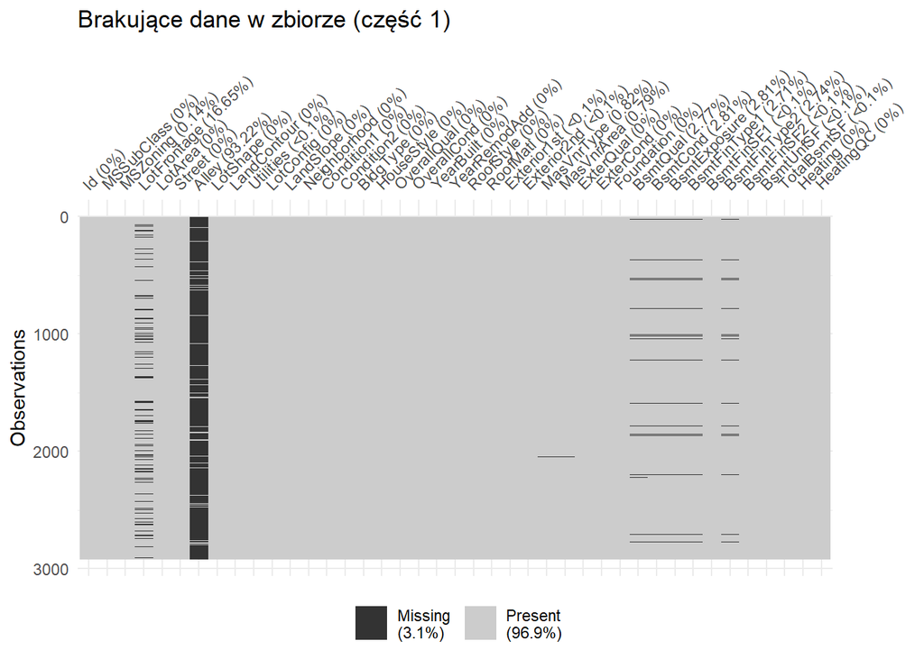

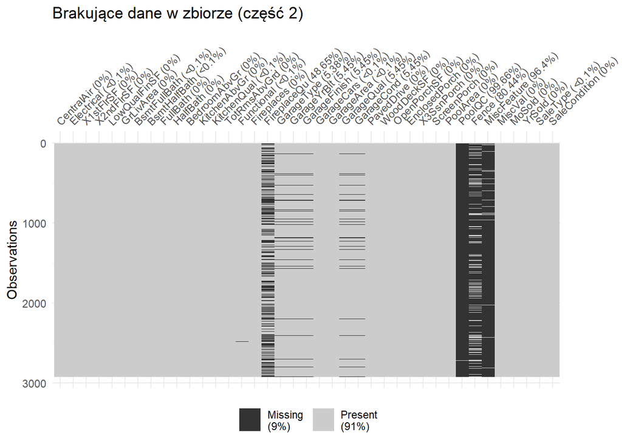

Jak widać w naszych danych występują kolumny z brakami danych. Jednak większość z nich występuje w specyficznym kontekście, ponieważ dotyczą głównie kolumn opisujących wyposażenie lub specyficzne pomieszczenia w mieszkaniu. Wartość NA ma oznaczać brak danej ‘funkcji’ w domu. Dlatego zamienimy wartości w tego typu kolumnach na `Absent` w przypadku kolumn typu string, natomiast na -1 w przypadku kolumn liczbowych.

```r
names_col <- c(
  "FireplaceQu", "GarageType", "GarageYrBlt", "GarageFinish", "GarageQual",
  "GarageCond", "PoolQC", "Fence", "MiscFeature", "Alley", "BsmtQual",
  "BsmtCond", "BsmtExposure", "BsmtFinType1", "BsmtFinType2")
real_estate <- real_estate1
for (i in 1:(length(names_col))) {
  n <- names_col[i]
  atr <- real_estate[[n]]
  if (is.character(atr)) {
    atr[is.na(atr)] <- "Absent"
    real_estate[n] <- atr
  }
  if (is.numeric(atr)) {
    atr[is.na(atr)] <- "-1"
    real_estate[n] <- atr
  }
}
```

Po zastosowaniu poprawki, liczba braków znacznie się zmniejszyła.

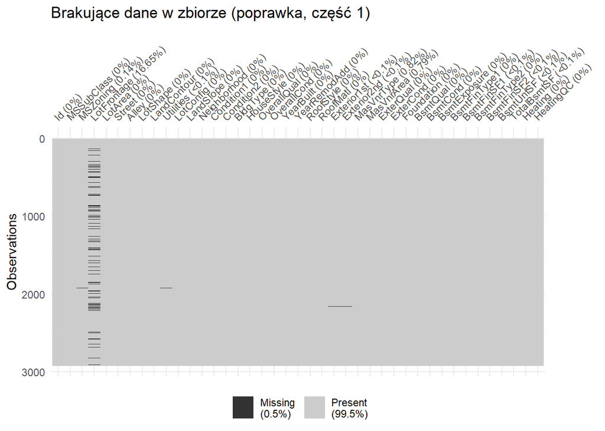

[figure not shown]

## Analiza rodzajów kolumn

```
## # A tibble: 1 x 3
##   columns discrete_columns continuous_columns
##     <int>            <int>              <int>
## 1      82               45                 37
```

Funkcja introduce rozpoznała w naszej kolumnie aż 37 kolumn ciągłych. Zapewne wynika to ze zliczenia kolumn numerycznych. Dużo kolumn numerycznych można jednak uznać za dyskretne, bo przyjmują wartości z ograniczonego zbioru np. liczba łazienek lub kuchni czy ocena ogólnych warunków.

```
## # A tibble: 6 x 3
##   MSSubClass BsmtCond BsmtQual
##        <int> <chr>    <chr>
## 1         60 TA       Gd
## 2         20 TA       Gd
## 3         60 TA       Gd
## 4         70 Gd       TA
## 5         60 TA       Gd
## 6         50 TA       Gd
```

Kolumna `MSSubClass`, która liczbami koduje typ nieruchomości może zostać zmieniona na typowo tekstową zmienną dyskretną. Natomiast kolumny opisujące jakość lub warunki niektórych elementów mieszkania, zamiast używać skrótów tekstowych, mogą używać skali liczbowej do oceny. Zmiany wymagają także inne kolumny, których wartości da się zakwalifikować jako reprezentujące relacje lepszy-gorszy.

Po wstępnym przetworzeniu danych, można stwierdzić, że zmienne w zbiorze można podzielić na 3 grupy: zmienne kategoryczne, typowo ciągłe oraz oceniające (uporządkowane kategoryczne), czyli takie, w których kryje się już ocena pewnych elementów.

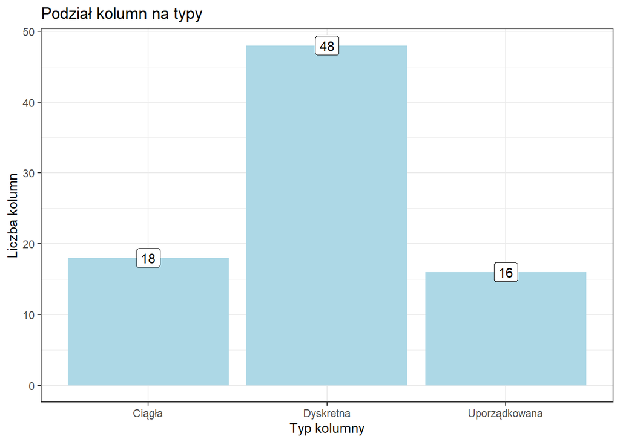

## Analiza niektórych zmiennych

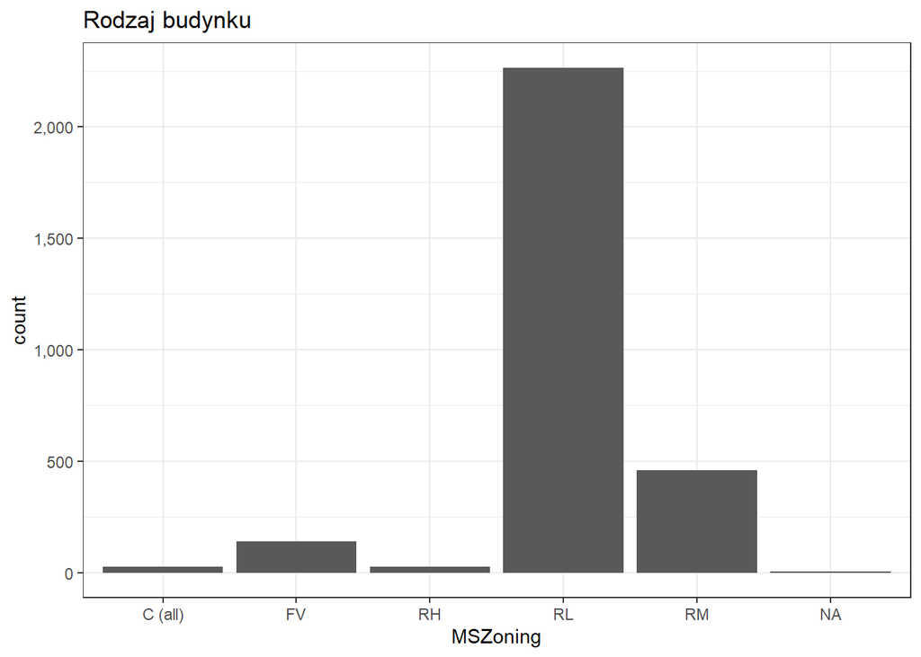

Jak widać przeważająca ilość nieruchomości to budynki mieszkalne o niskiej lub średniej gęstości.

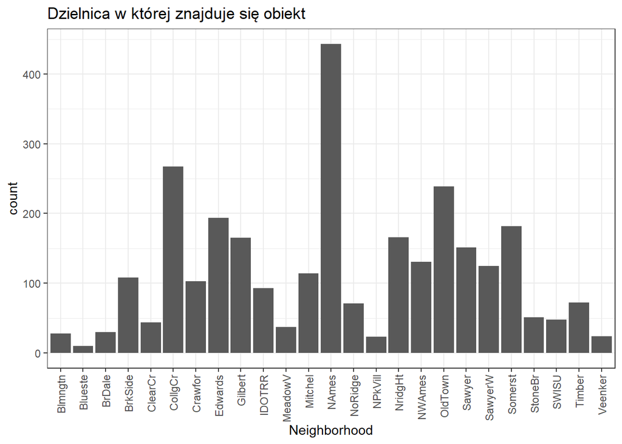

Położenie budynków jak widać nie jest równomiernie rozłożone na tle dzielnic, najwięcej nieruchomości jest z Północnego Ames. Dzielnica ta znacząco wyróżnia się na tle pozostałych. Są także dzielnice jak np. Blueste gdzie widać bardzo małą ilość obiektóW które były na sprzedaż.

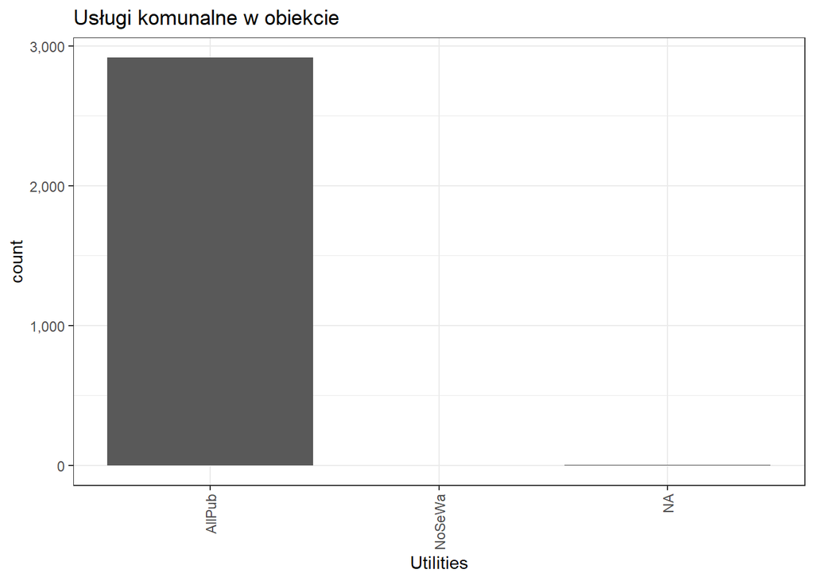

Jak widać zmienna ta nie wnosi żadnej wartości w nasze dane, praktycznie wszystkie obiekty poza pojedynczymi przypadkami mają wszystkie usługi. Analizowanie zmiennej dla której wszystkie obserwacje mają tą samą wartość nie ma sensu.

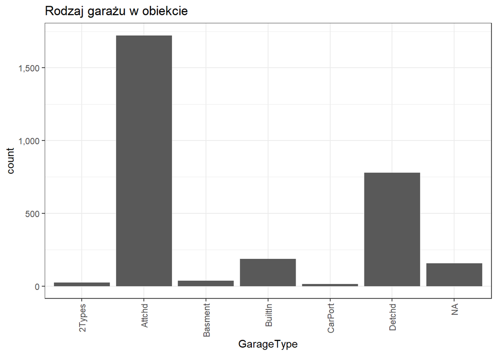

Jak widać przeważająca ilość domóW ma garaże wbudowane lub dołączane do domów.

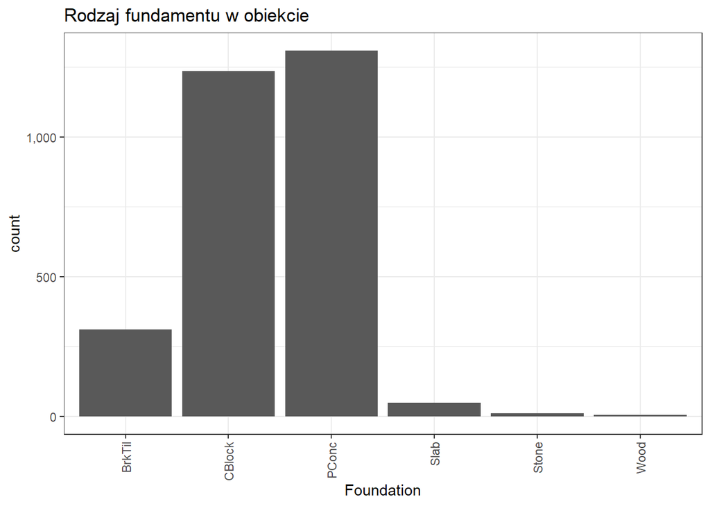

Można zauważyć, że pomimo iż rodzai fundamentóW jest 6, to większość obiektów ma tak na prawdę 1 z 3 rodzajów.

## Zależości między zmiennymi

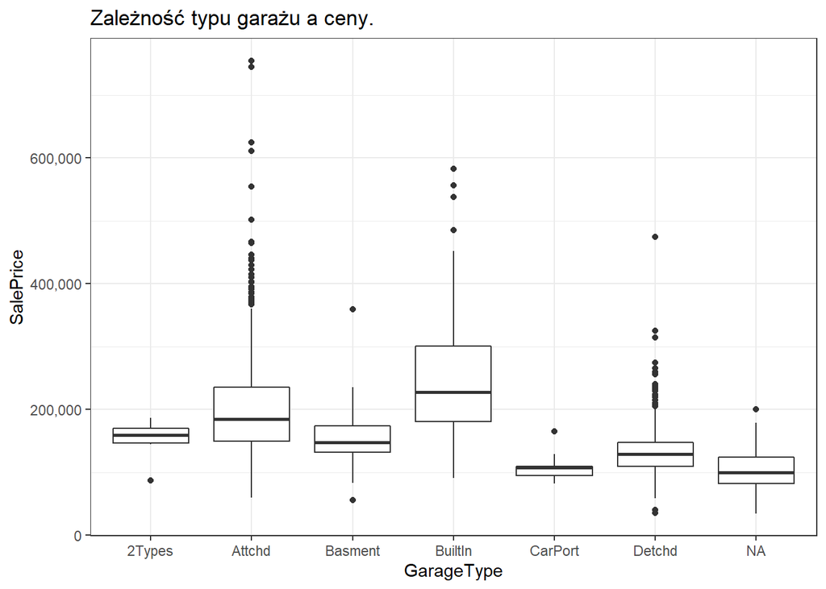

Na wykresie pomiędzy typem garażu, a ceną domu widać, że największą różnorodność cen mają nieruchomości z garażem wbudowanym w dom albo przyłączonym do niego. Nieruchomości z wbudowanym garażem mają także najwyższą medianę cen, następnie za nimi domy z przyłączanym. Co interesujące to pomimo, że obiekty z wbudowanym garażem mają medianę cen najwyższą to najdroższe domy ze wszystkich mają garaże przyłączane do nich.

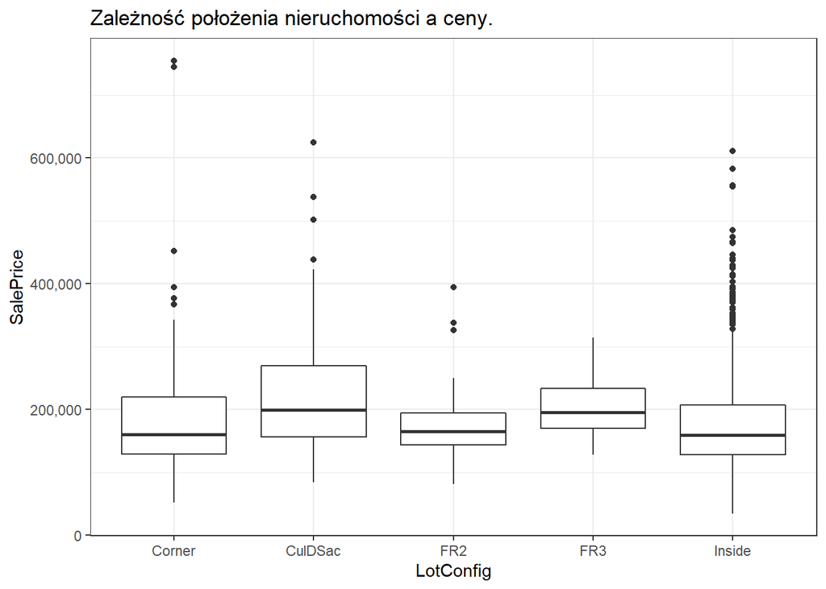

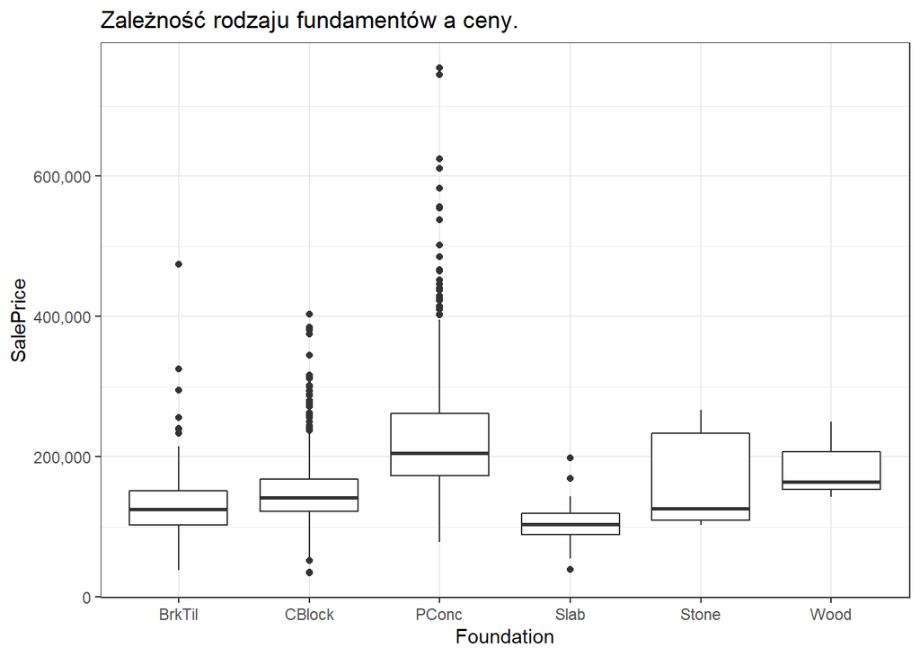

O ile górny kwantyl ceny dla nieruchomości o kamiennych oraz betonowych fundamentach jest zbliżony do siebie, to widać stosunkowo niską medianę cen dla domów z kamiennymi fundamentami. Także najdroższe domy to przede wszystkim takie o betonowych fundamentach.

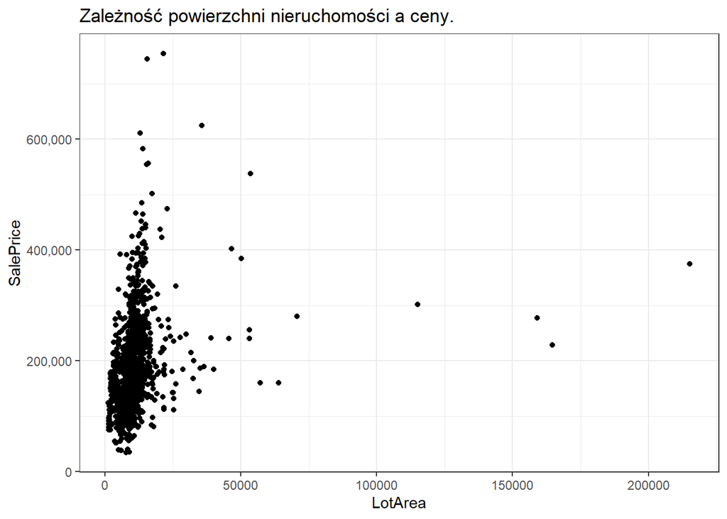

Na wykresie tym chcieliśmy sprawdzić zależność pomiędzy ceną nieruchomości a wielkością. Widać pewną zależność, że im większa powierzchnia tym cena większa. Istnieją jednak pewne przypadki odstające dla których pomimo dużej wielkości cena jest względnie niska, oraz odwrotnie.

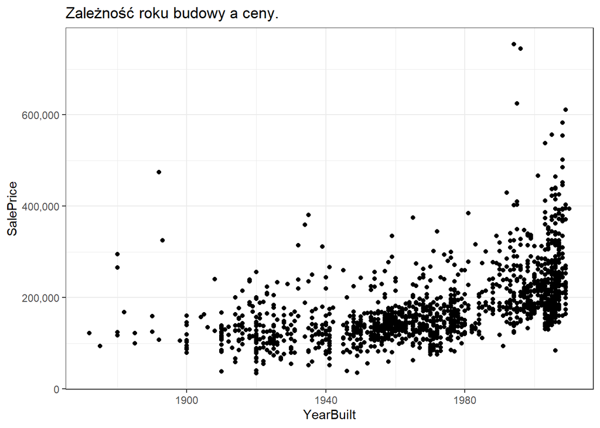

Z tego wykresu można wywnioskować, że im nowsze nieruchomości tym ich cena jest większa, można także wyróżnić trzy skupiska obiektów, jedno do lat 40, drugie do lat 80, a trzecie w czasach współczesnych.

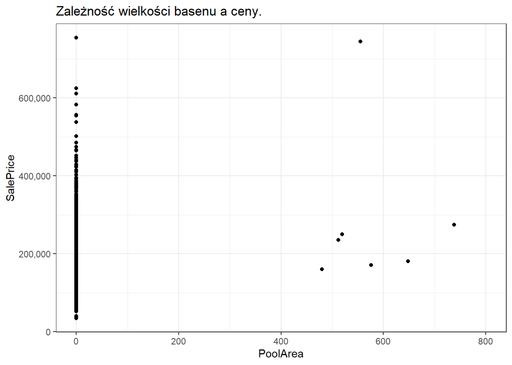

Chcieliśmy tutaj zobaczyć czy wielkość basenu wpływa na cenę, jednak jak widać większość nieruchomości ma zerową powierzchnie basenu co jest równoznaczne z jego brakiem. A więc oznacza to, że wszystkie zmienne opisujące basen takie jak: jego wielkość, jakość, etc ciężko brać pod uwagę przy wycenie.

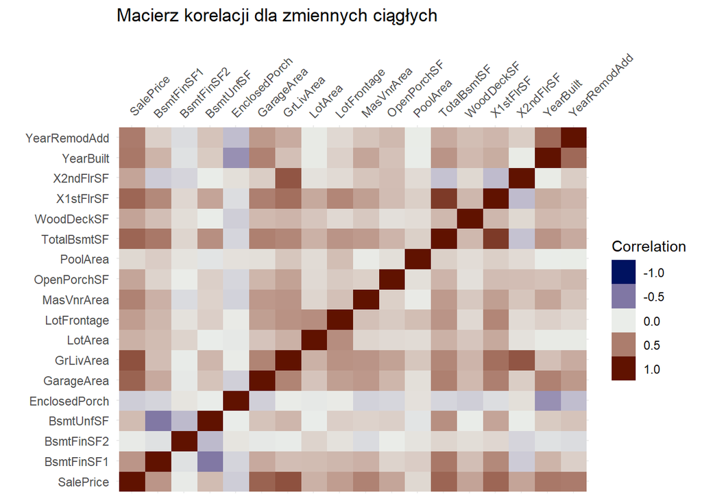

Nie występują bardzo silne korelacje dodatnie w naszych zmiennych ciągłych, z kilkoma wyjątkami. Co ciekawe, jest bardzo mało ujemnych korelacji. Jest możliwe, że jest to spowodowane specyfiką nieruchomości. Jeżeli dom stoi na dużej działce, to najprawdopodobniej będzie proporcjonalny do niej.

## Podsumowanie

Po wstępnym zapoznaniu się z danymi, możemy stwierdzić, że na pewno nasz zbiór jest bogaty w informacje. Dzięki 79 zmiennym mamy szeroki opis każdego z rekordów. Krotka analiza zależności wskazała na których kolumnach powinniśmy się skupić bardziej. To kolumny związane z fundamentami, garażem, rokiem wybudowania i powierzchnią mogą mieć znaczenie przy określaniu ceny. Znaczące mogą być także zmienne uporządkowane zawierające w sobie ocenę. Odkryliśmy także, że w niektórych kolumnach kategorycznych, mimo występowania kilku wartości, to wyraźne dominuje tylko jedna. Wiemy, że nie musimy poświęcać im więcej uwagi w pierwszej kolejności, gdyż mogą się okazać mało znaczące w dalszej predykcji.